# TCGA RNASeq Counts EDA—KIRC

Ariel Balter

11 January, 2022

# 1 Source

# 2 PanCan Atlas

https://gdc.cancer.gov/about-data/publications/pancanatlas

# 3 GDC—Workflow and Normalization

GDC gives very explicit details about their pipelines, including the actual code.

- RNASeq: https://docs.gdc.cancer.gov/Data/Bioinformatics_Pipelines/Expression_mRNA_Pipeline/
- MAF: https://docs.gdc.cancer.gov/Data/File_Formats/MAF_Format/

More information and data types, sources, and processing is in the [Data Dictionary](https://docs.gdc.cancer.gov/Data_Dictionary/viewer/).

It’s clear from the description and flowchart that the GDC pipeline does not do any normalization other than within sample FPKM and upper quantile normalized FPKM. Details are given the the pages linked to above. These are the values in the RNASeq file mentioned above. Still, as shown below, the across-sample data has a fairly consistent range. This suggests either incredible attention to detail in every step from processing samples to sequencing, or something else that I have not found documented yet.

The [GDC Data Portal](https://portal.gdc.cancer.gov/) is another source for data. The link they have for a description of the data links to the data dictionary described above.

# 4 TCGA

[This GDC page](https://gdc.cancer.gov/about-data/publications/PanCan-Clinical-2018) on the TCGA Pan-Cancer project links to some additional resources

# 5 ISB-CGC

[ISB-CGC](https://isb-cancer-genomics-cloud.readthedocs.io/en/latest/sections/PanCancer-Atlas-Mirror.html) hosts the raw data from GDC and other project in multiple formats, including BigQuery tables. This is actually where I am drawing data for this analysis.

I communicated with ISB-CGC.

> We have an exhaustive ETL process that does that huge manifest / download from the GDC portal. We’ve also got the Pancancer Atlas data in BQ format in our isb-cgc-bq.pancancer_atlas dataset

# 6 Set up BigQuery connection

```r
bq_auth(email = "ariel.balter@providence.org")
isb_conn = dbConnect(
  bigquery(),
  project="eacri-cancer-graph"
)
```

# 7 Choose a TCGA Project ID to Start With

Here we will look at the Colon adenocarcinoma (KIRC) subset.

```r
tcga_project = "KIRC"
```

# 8 Mutations EDA

This table is somewhat like a VCF file. It lists somatic mutations found in tumor samples and has annotated these with gene symbols, various variant classifications, and other information. Based on the `Variant_Classifiction` column, we will select only genes/regions that have coding consequences—i.e. are code for amino acids critical for downstream pathways.

This comes straight from the ISB-CGC maintained tables of the TCGA data.

Selecting the project KIRC.

## 8.1 Download from BigQuery

**NOTE:** We are only interested in the barcodes for tumor samples

```r
project_short_name = glue("TCGA-{tcga_project}")

mutations =

  tbl(isb_conn, "isb-cgc-bq.TCGA.somatic_mutation_hg38_gdc_current") %>%

  ### Just keep selected project
  filter(project_short_name == "TCGA-KIRC") %>%
  # filter(project_short_name %like% project_short_name) %>%
  # filter(project_short_name == project_short_name)

  ### Ignore most columns for now
  select(
    gene_symbol = Hugo_Symbol,
    variant_classification = Variant_Classification,
    sample_barcode = sample_barcode_tumor,
    sift = SIFT,
    poly_phen = PolyPhen,
    # vep = VEP
    impact = IMPACT
  ) %>%

  ### Download the table
  collect()

object.size(mutations) %>% print(units = "MB", standard = "SI")
```

```
2.2 MB
```

## 8.2 Summary

```r
feature_count_summary =
  mutations %>%
  summarize(
    Num_Genes = n_distinct(gene_symbol),
    Num_Samples = n_distinct(sample_barcode),
    Num_Pairs = n_distinct(paste0(gene_symbol, sample_barcode))
  )

feature_count_summary %>% displayTable()
```

| Num_Genes | Num_Samples | Num_Pairs |
| --- | --- | --- |
| 12637 | 336 | 27938 |

# 9 RNASeq Counts

We created our own BigQuery tables from the ISB-CGC RNASeq table split into TCGA Study/Project groups to make downloading the data feasible. Otherwise we query the ISB-CGC table and filter by cancer time which results in a longer and more expensive query.

Selected project: KIRC

```r
table_name = paste0("eacri-cancer-graph.ISB_TCGA.", tcga_project)

print(glue("Table Name: {table_name}"))
```

```
Table Name: eacri-cancer-graph.ISB_TCGA.KIRC
```

```r
rnaseq_counts =
  tbl(isb_conn, table_name) %>%

  filter(project_short_name == "TCGA-KIRC") %>%

  select(
    gene_symbol = gene_name,
    sample_barcode,
    HTSeq__Counts,
    HTSeq__FPKM,
    HTSeq__FPKM_UQ
  ) %>%


  # filter(gene_symbol %in% random_genes) %>%

  ### The RNASeq table has counts for many samples besides the tumor
  ### samples for which we have mutation data. We only want to include
  ### the samples for which we have mutation data. We are interested in
  ### changes in expression in wildtype samples (for a given gene).
  ### However, a sample not being in the mutation table may not
  ### necessarily mean that it is wildtype in all genes. It could
  ### simply mean that TCGA did not include variant calls for that
  ### sample in the mutation table.
  ###
  ###         IS THIS TRUE????          ####
  ###         ----------------          ####
  # filter(sample_barcode %in% tumor_barcodes) %>%
  collect()

# vroom_write(counts_and_mutations, file="large_files/KIRC-rnaseq.tsv")
# counts_and_mutations = vroom("large_files/KIRC-rnaseq.tsv")

# saveRDS(counts_and_mutations, file="large_files/KIRC-rnaseq.rds")
# counts_and_mutations = readRDS("large_files/KIRC-rnaseq.rds")

tibble(rnaseq_counts = colnames(rnaseq_counts)) %>%
  displayTable(caption = "Columns in Counts Table")
```

| rnaseq_counts |
| --- |
| gene_symbol |
| sample_barcode |
| HTSeq__Counts |
| HTSeq__FPKM |
| HTSeq__FPKM_UQ |

```r
rnaseq_counts %>%
  head() %>%
  collect() %>%
  displayTable(caption = "Sample of Data")
```

| gene_symbol | sample_barcode | HTSeq__Counts | HTSeq__FPKM | HTSeq__FPKM_UQ |
| --- | --- | --- | --- | --- |
| Y_RNA | TCGA-B2-4101-01A | 0 | 0 | 0 |
| Y_RNA | TCGA-G6-A8L8-01A | 0 | 0 | 0 |
| Y_RNA | TCGA-A3-3376-01A | 0 | 0 | 0 |
| Y_RNA | TCGA-CJ-4870-01A | 0 | 0 | 0 |
| RN7SKP54 | TCGA-B0-4833-01A | 0 | 0 | 0 |
| RN7SL48P | TCGA-B2-5633-01A | 0 | 0 | 0 |

```r
object.size(rnaseq_counts) %>% print(units = "MB", standard = "SI")
```

```
1334 MB
```

# 10 Combined table

For downstream analysis we join the MAF and RNASeq tables on the gene symobls and sample barcodes.

**Question:** Were the sample/gene pairs in the MAF table processed the same way as the ones not in the MAF table?

**Question:** Do we presume sample/gene pairs not in the MAF table do not have mutations? That would seem odd, since these are all tumor samples.

**NOTE:** we are adding a variable `gene_source` that captures whether that sample is or is not included in the MAF file. That is, were somatic mutations called for that sample.

## 10.1 Samples in MAF vs RNASeq Tables

```r
mutation_barcodes =
  mutations %>%
  pull(sample_barcode) %>%
  unique()

rnaseq_barcodes =
  rnaseq_counts %>%
  pull(sample_barcode) %>%
  unique()

tibble(
  "Samples in MAF File" = length(mutation_barcodes),
  "Samples in RNASeq File" = length(rnaseq_barcodes),
  "Samples in Both" = intersect(mutation_barcodes, rnaseq_barcodes) %>% length()
) %>%
displayTable()
```

| Samples in MAF File | Samples in RNASeq File | Samples in Both |
| --- | --- | --- |
| 336 | 607 | 332 |

## 10.2 Genes in MAF vs RNASeq Tables

```r
mutation_genes =
  mutations %>%
  pull(gene_symbol) %>%
  unique()

rnaseq_genes =
  rnaseq_counts %>%
  pull(gene_symbol) %>%
  unique()

tibble(
  "Genes in MAF File" = length(mutation_genes),
  "Genes in RNASeq File" = length(rnaseq_genes),
  "Genes in Both" = intersect(mutation_genes, rnaseq_genes) %>% length()
) %>%
displayTable()
```

| Genes in MAF File | Genes in RNASeq File | Genes in Both |
| --- | --- | --- |
| 12637 | 58387 | 12593 |

## 10.3 Join the Tables

```r
counts_and_mutations =

  ### Left join to keep all genes with rnaseq counts, even if they
  ### don't show up in the MAF table.
  full_join(

    rnaseq_counts %>%
      mutate(in_rnaseq_table = T),

    ### Add column to remember source of gene-sample pair
    mutations %>%
      mutate(in_maf_table = T),

    by = c("gene_symbol", "sample_barcode"),

    suffix = c(".maf", ".rnaseq")

  ) %>%

  mutate(
    ### Because we perform a left join into the rnaseq table,
    ### sample/gene pairs not in the MAF table will be NA.
    ### change to Not In MAF Table
    in_maf_table = ifelse(is.na(in_maf_table), F, T),
    in_rnaseq_table = ifelse(is.na(in_rnaseq_table), F, T),
    maf_only = ifelse(in_maf_table & !in_rnaseq_table, T, F),
    rnaseq_only = ifelse(in_rnaseq_table & !in_maf_table, T, F)
  ) %>%

  filter(sample_barcode %in% mutation_barcodes) %>%

  mutate(gene_source = case_when(
    maf_only ~ "MAF Table",
    rnaseq_only ~ "RNASeq Table",
    T ~ "Both Tables"
  ))


## Delete tables no longer needed to save memory
rm(mutations)
rm(rnaseq_counts)
gc()
```

```
            used   (Mb) gc trigger   (Mb)  max used   (Mb)
Ncells   1438559   76.9    2331182  124.5   2331182  124.5
Vcells 234895289 1792.2  750277687 5724.2 937496044 7152.6
```

## 10.4 Some Stats

```r
counts_and_mutations %>%
  select(gene_symbol, gene_source) %>%
  distinct() %>%
  count(gene_source) %>%
  displayTable()
```

| gene_source | n |
| --- | --- |
| Both Tables | 12520 |
| MAF Table | 379 |
| RNASeq Table | 58387 |

```r
counts_and_mutations %>%
  select(sample_barcode, maf_only, rnaseq_only) %>%
  distinct() %>%
  count(maf_only, rnaseq_only) %>%
  displayTable(caption = "Samples in MAF table vs RNASeq table")
```

| maf_only | rnaseq_only | n |
| --- | --- | --- |
| False | False | 332 |
| False | True | 332 |
| True | False | 96 |

```r
counts_and_mutations %>%
  select(sample_barcode, in_maf_table, in_rnaseq_table) %>%
  distinct() %>%
  count(in_maf_table, in_rnaseq_table) %>%
  displayTable(caption = "Samples in MAF table vs RNASeq table")
```

| in_maf_table | in_rnaseq_table | n |
| --- | --- | --- |
| False | True | 332 |
| True | False | 96 |
| True | True | 332 |

```r
counts_and_mutations %>%
  summarize(n_distinct(gene_symbol)) %>%
  displayTable(caption="Number of distinct genes")
```

| n_distinct(gene_symbol) |
| --- |
| 58431 |

```r
counts_and_mutations %>%
  group_by(in_rnaseq_table, in_maf_table) %>%
  summarize(n_distinct(gene_symbol)) %>%
  displayTable(caption = "Genes in MAF table vs RNASeq table")
```

| in_rnaseq_table | in_maf_table | n_distinct(gene_symbol) |
| --- | --- | --- |
| False | True | 379 |
| True | False | 58387 |
| True | True | 12520 |

# 11 Sample-Wise Expression Counts EDA

## 11.1 Overall Summary

```r
counts_and_mutations %>%
  summarize(
    N_Samples = n_distinct(sample_barcode),
    N_Genes = n_distinct(gene_symbol),
    N_Pairs = n_distinct(paste0(gene_symbol, sample_barcode))
  )
```

| N_Samples | N_Genes | N_Pairs |
| --- | --- | --- |
| 336 | 58431 | 19384948 |

## 11.2 Raw Counts

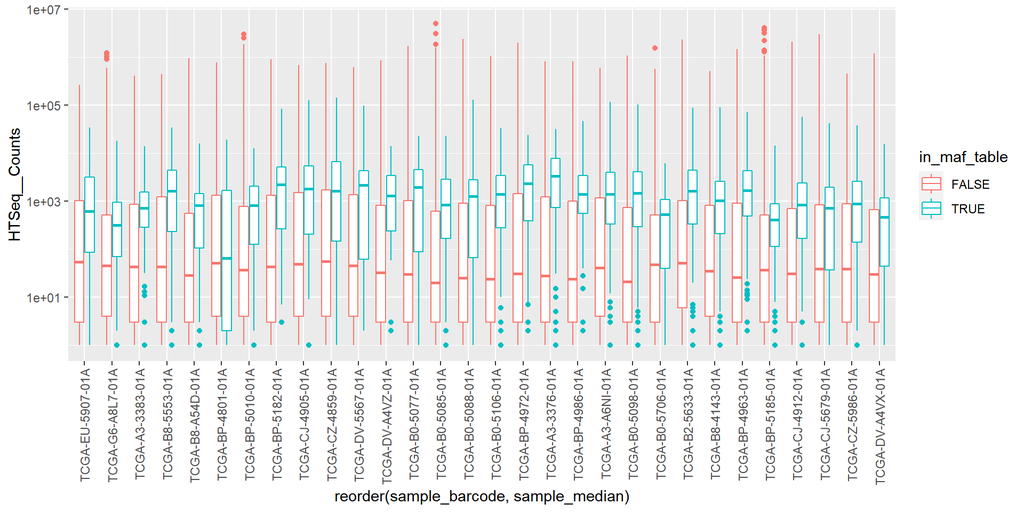

```r
sample_barcodes =
  counts_and_mutations %>%
  select(sample_barcode) %>%
  distinct() %>%
  pull()

counts_and_mutations %>%

  filter(sample_barcode %in% sample(sample_barcodes, 30)) %>%

  group_by(sample_barcode) %>%
    mutate(sample_median = median(HTSeq__Counts)) %>%
  ungroup() %>%
  # filter(gene_median > 100) %>%
  ggplot(aes(
    x = reorder(sample_barcode, sample_median),
    y=HTSeq__Counts,
    color=in_maf_table
  )) +
  # geom_violin() +
  geom_boxplot() +
  # geom_quasirandom(size = 0.1) +
  scale_y_log10() +

  theme(axis.text.x = element_text(angle = 90, vjust = 0.5, hjust=1))
```

## 11.3 FPKM Upper Quantile Normalized

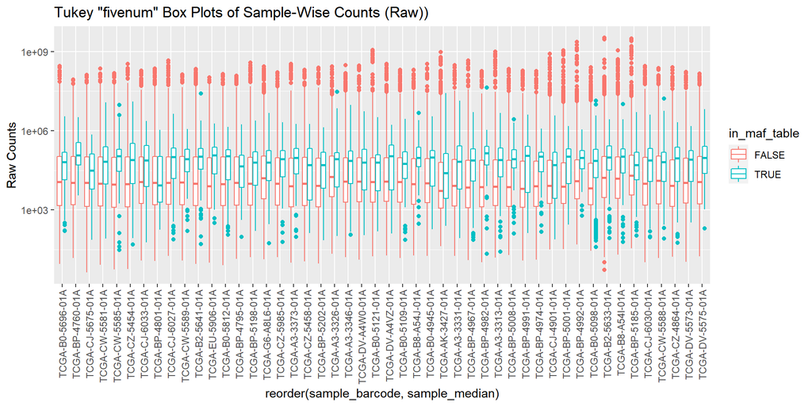

```r
sample_barcodes =
  counts_and_mutations %>%
  select(sample_barcode) %>%
  distinct() %>%
  pull()

counts_and_mutations %>%

  filter(sample_barcode %in% sample(sample_barcode, 50)) %>%

  group_by(sample_barcode) %>%
    mutate(sample_median = median(HTSeq__FPKM_UQ)) %>%
  ungroup() %>%
  # filter(gene_median > 100) %>%
  ggplot(aes(
    x = reorder(sample_barcode, sample_median),
    y=HTSeq__FPKM_UQ,
    color=in_maf_table
  )) +
  # geom_violin() +
  geom_boxplot() +
  # geom_quasirandom(size = 0.1) +
  scale_y_log10() +
  theme(axis.text.x = element_text(angle = 90, vjust = 0.5, hjust=1)) +
  ggtitle("Tukey \"fivenum\" Box Plots of Sample-Wise Counts (Raw))") +
  ylab("Raw Counts")
```

## 11.4 Observations

1. The quantile boxes (25%, median, 75%) across samples look very comparable. I would definitely have not expected this with raw counts. I need to examine the TCGA workflow outlines carefully to see if some kind of normalization was done prior to the HTSeq step.
2. The counts for genes in both the MAF table vs. those not in the MAF table look quite different. As shown below, in both cases, the medians of the RNASeq table only genes are statistically significantly lower.

## 11.5 Sample-Wise Descriptive Stats

```r
descriptive_stats =
  counts_and_mutations %>%
  pivot_longer(
    cols = starts_with("HTSeq"),
    names_to = "counts_type",
    values_to = "counts"
  ) %>%
  group_by(sample_barcode, in_maf_table, counts_type) %>%
    summarize(
      Min = min(counts),
      Q1 = quantile(counts, 0.25, na.rm=T),
      Median = median(counts, na.rm=T),
      Mean = mean(counts, na.rm=T),
      SD = sd(counts, na.rm=T),
      Var = var(counts, na.rm=T),
      Q3 = quantile(counts, 0.75, na.rm=T),
      Max = max(counts),
      IQR = Q3 - Q1
    ) %>%
  arrange(Max) %>%
  tail(-1) %>%
  ungroup() %>%
  ungroup()
object.size(descriptive_stats)
```

```
262344 bytes
```

```r
gc()
```

```
            used   (Mb) gc trigger    (Mb)   max used    (Mb)
Ncells   1576881   84.3    6501723   347.3   24802098  1324.6
Vcells 288949699 2204.6 1407395316 10737.6 1465959969 11184.4
```

## 11.6 Median vs. IQR

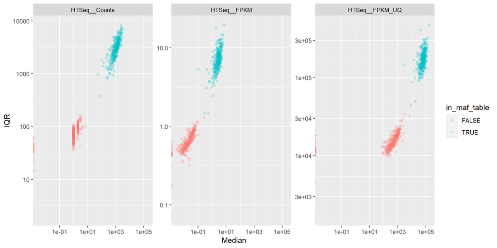

```r
descriptive_stats %>%
  ggplot(aes(x=Median, y=IQR, color=in_maf_table)) +
  geom_point(alpha = 0.2) +
  scale_x_log10() +
  scale_y_log10() +
  facet_wrap(
    ~counts_type,
    ncol=3,
    scales="free_y",
    strip.position = "top"
  )
```

## 11.7 How do Counts Compare Between Different Variant Classes

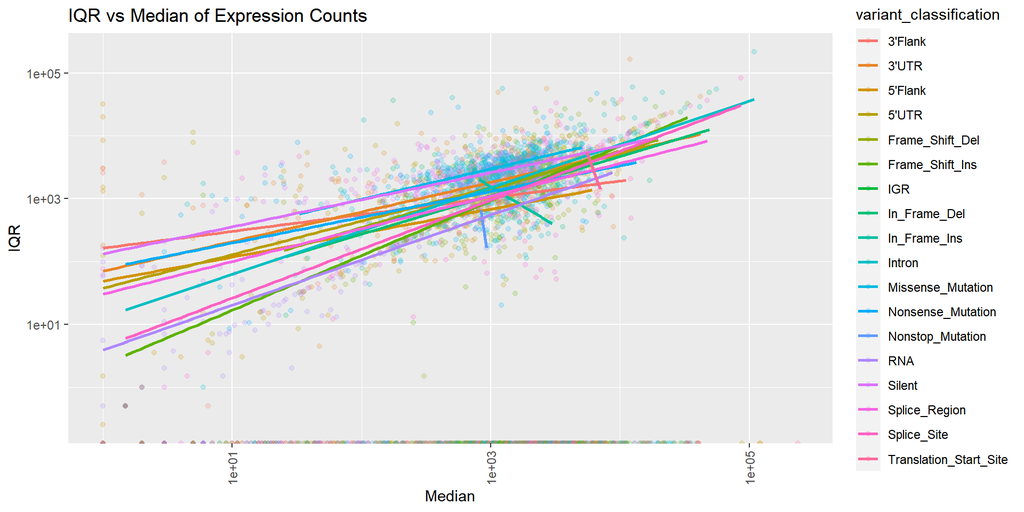

```r
variant_classifications =
  counts_and_mutations %>%
  pull(variant_classification) %>%
  unique()

descriptive_stats_with_variant_class =
  counts_and_mutations %>%
  pivot_longer(
    cols = starts_with("HTSeq"),
    names_to = "counts_type",
    values_to = "counts"
  ) %>%
  filter(counts_type == "HTSeq__Counts") %>%
  mutate(counts = counts + 1) %>%
  group_by(sample_barcode, in_maf_table, variant_classification) %>%
    summarize(
      Min = min(counts),
      Q1 = quantile(counts, 0.25, na.rm=T),
      Median = median(counts, na.rm=T),
      Mean = mean(counts, na.rm=T),
      SD = sd(counts, na.rm=T),
      Var = var(counts, na.rm=T),
      Q3 = quantile(counts, 0.75, na.rm=T),
      Max = max(counts),
      IQR = Q3 - Q1
    ) %>%
  arrange(Max) %>%
  tail(-1) %>%
  ungroup() %>%
  ungroup()
descriptive_stats_with_variant_class %>%
  filter(in_maf_table==T) %>%
  ggplot(aes(x=Median, y=IQR, color=variant_classification)) +
  geom_point(alpha = 0.2) +
  scale_x_log10() +
  scale_y_log10() +
  geom_smooth(method=lm, formula=y~x, size=1, se=F) +
  ggtitle(
    "IQR vs Median of Expression Counts"
  ) +

  theme(axis.text.x = element_text(angle = 90, vjust = 0.5, hjust=1))
```

```r
rm(descriptive_stats_with_variant_class)

gc()
```

```
            used   (Mb) gc trigger   (Mb)   max used    (Mb)
Ncells   2749881  146.9    6501723  347.3   24802098  1324.6
Vcells 254035249 1938.2 1125916253 8590.1 1465959969 11184.4
```

**Observation:** Other than the possible outlier of `Nonstop_Mutation` The relationship between Median and IQR across variant classes is basically the same.

## 11.8 Mean vs. Variance

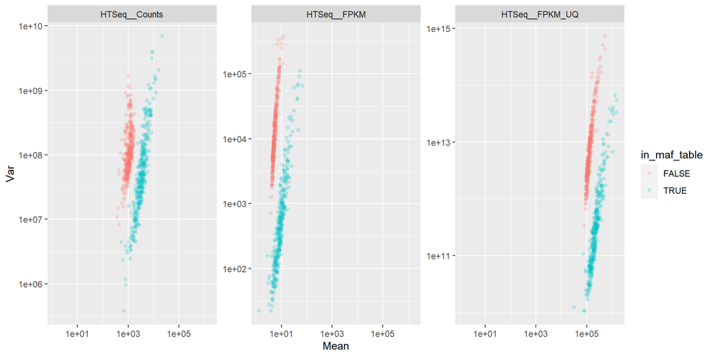

```r
descriptive_stats %>%
  ggplot(aes(x=Mean, y=Var, color=in_maf_table)) +
  geom_point(alpha = 0.2) +
  scale_x_log10() +
  scale_y_log10() +
  facet_wrap(
    ~counts_type,
    ncol=3,
    scales="free_y",
    strip.position = "top"
  )
```

## 11.9 Observations

1. Something is definitely different between the two sources of counts.
2. In Poisson counts, the variance should be equal to the mean. In this case, we have a powerlaw with slope greater than 2.
3. It seems especially odd that the fpkm normalized counts show greater difference than the raw ones.

## 11.10 Testing – Raw

```r
raw = descriptive_stats %>%
  filter(counts_type == "HTSeq__Counts") %>%
  lm(Median ~ in_maf_table, .)
summary(raw)
```

```
Call:
lm(formula = Median ~ in_maf_table, data = .)

Residuals:
     Min       1Q   Median       3Q      Max
-1136.75   -72.50    -0.28     1.72  1979.25

Coefficients:
                 Estimate Std. Error t value Pr(>|t|)
(Intercept)         1.277     22.793   0.056    0.955
in_maf_tableTRUE 1135.471     32.234  35.226   <2e-16 ***
---
Signif. codes:  0 '***' 0.001 '**' 0.01 '*' 0.05 '.' 0.1 ' ' 1

Residual standard error: 415.3 on 662 degrees of freedom
  (4 observations deleted due to missingness)
Multiple R-squared:  0.6521,    Adjusted R-squared:  0.6516
F-statistic:  1241 on 1 and 662 DF,  p-value: < 2.2e-16
```

## 11.11 Testing – FPKM UQ

```r
fpkm_uq = descriptive_stats %>%
  filter(counts_type == "HTSeq__FPKM_UQ") %>%
  lm(Median ~ in_maf_table, .)
summary(fpkm_uq)
```

```
Call:
lm(formula = Median ~ in_maf_table, data = .)

Residuals:
   Min     1Q Median     3Q    Max
-65455   -620   -149    865 114886

Coefficients:
                 Estimate Std. Error t value Pr(>|t|)
(Intercept)           581        940   0.618    0.537
in_maf_tableTRUE    64874       1329  48.799   <2e-16 ***
---
Signif. codes:  0 '***' 0.001 '**' 0.01 '*' 0.05 '.' 0.1 ' ' 1

Residual standard error: 17130 on 662 degrees of freedom
  (4 observations deleted due to missingness)
Multiple R-squared:  0.7825,    Adjusted R-squared:  0.7821
F-statistic:  2381 on 1 and 662 DF,  p-value: < 2.2e-16
```

# 12 Gene-Wise Counts EDA

## 12.1 Gene-Wise Counts

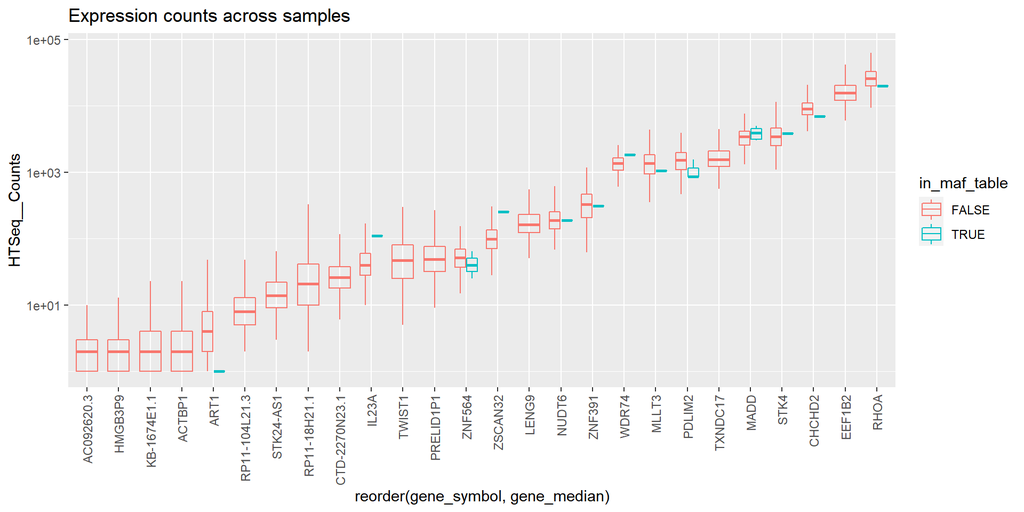

```r
gene_symbols =
  counts_and_mutations %>%
  select(gene_symbol) %>%
  distinct() %>%
  pull()

counts_and_mutations %>%
  filter(gene_symbol %in% sample(gene_symbols, 50)) %>%

  group_by(gene_symbol) %>%

    mutate(gene_median = median(HTSeq__Counts)) %>%
  ungroup() %>%

  filter(gene_median > 0) %>%

  ggplot(aes(
    x = reorder(gene_symbol, gene_median),
    y=HTSeq__Counts,
    color=in_maf_table
  )) +
  # geom_violin() +
  geom_boxplot(alpha = 0) +
  # geom_quasirandom() +
  scale_y_log10() +
  theme(axis.text.x = element_text(angle = 90, vjust = 0.5, hjust=1)) +
  ggtitle("Expression counts across samples")
```

## 12.2 Gene-Wise Descriptive Stats

```r
descriptive_stats =
  counts_and_mutations %>%
  pivot_longer(
    cols = starts_with("HTSeq"),
    names_to = "counts_type",
    values_to = "counts"
  ) %>%
  group_by(gene_symbol, in_maf_table, counts_type) %>%
    summarize(
      Min = min(counts),
      Q1 = quantile(counts, 0.25, na.rm=T),
      Median = median(counts, na.rm=T),
      Mean = mean(counts, na.rm=T),
      SD = sd(counts, na.rm=T),
      Var = var(counts, na.rm=T),
      Q3 = quantile(counts, 0.75, na.rm=T),
      Max = max(counts),
      IQR = Q3 - Q1
    ) %>%
  arrange(Max) %>%
  tail(-1) %>%
  ungroup()
gc()
```

```
            used   (Mb) gc trigger   (Mb)   max used    (Mb)
Ncells   2669845  142.6    7842067  418.9   24802098  1324.6
Vcells 256996480 1960.8 1297196323 9896.9 1465959969 11184.4
```

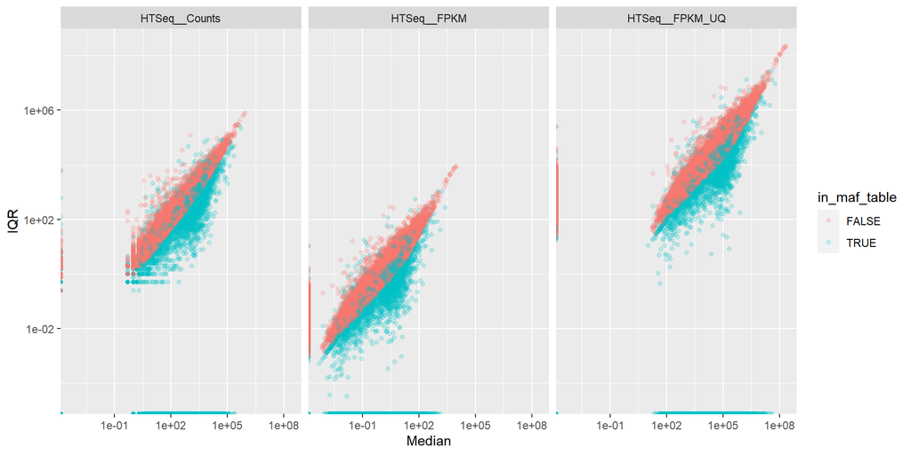

```r
descriptive_stats %>%
  ggplot(aes(x=Median, y=IQR, color=in_maf_table)) +
  geom_point(alpha = 0.2) +
  scale_x_log10() +
  scale_y_log10() +
  facet_wrap(
    ~counts_type,
    ncol=3,
    scales="free_y",
    strip.position = "top"
  ) +
  facet_wrap(~counts_type)
```

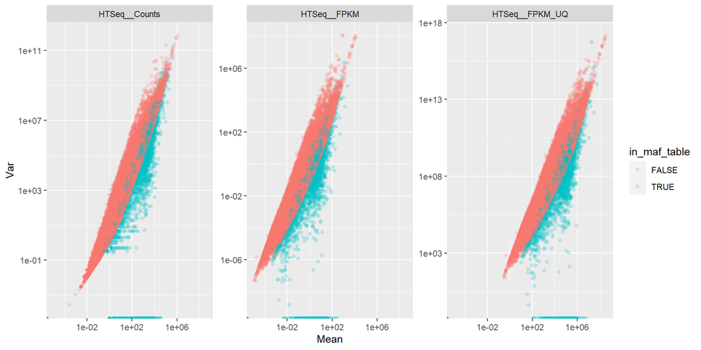

```r
descriptive_stats %>%
  ggplot(aes(x=Mean, y=Var, color=in_maf_table)) +
  geom_point(alpha = 0.2) +
  scale_x_log10() +
  scale_y_log10() +
  facet_wrap(
    ~counts_type,
    ncol=3,
    scales="free_y",
    strip.position = "top"
  )
```